# Reproducible Research: Peer Assessment 1

## Loading and preprocessing the data

### Let see if the file is in the directory and unzip it if needed, then load the data

```r
if (any(file.exists("activity.csv", "activity.zip"))) {

    # Unzipping file if needed
    if (!file.exists("activity.csv")) {
        unzip("activity.zip")
    }

    # Reading data from file
    data <- read.table("activity.csv", header = TRUE, sep = ",")
}
```

## What is mean total number of steps taken per day?

For this part of the assignment we are asked to make a histogram of the total number of steps taken each day, we can ignore the missing values in the dataset.

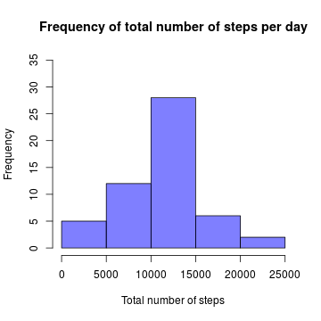

```r
# tot: total number of steps taken each day
tot <- tapply(data$steps, data$date, sum)
# plots the histogram whith default breaks require(ggplot2) qplot(tot,
# binwidth=2500)+geom_histogram(colour='black', fill='blue',binwidth=2500)
hist(tot, col = rgb(0, 0, 1, 0.5), main = "Frequency of total number of steps per day",
    xlab = "Total number of steps", ylab = "Frequency", ylim = c(0, 35))
```

We then need to calculate and report the mean and median total number of steps taken per day

```r
# calculates the mean of tot: the vector of the total number of steps per
# day, ignoring NA's
meantot <- mean(tot, na.rm = TRUE)
meantot
```

```
## [1] 10766
```

```r
# calculates the median of tot: the vector of the total number of steps per
# day, ignoring NA's
mediantot <- median(tot, na.rm = TRUE)
mediantot
```

```
## [1] 10765
```

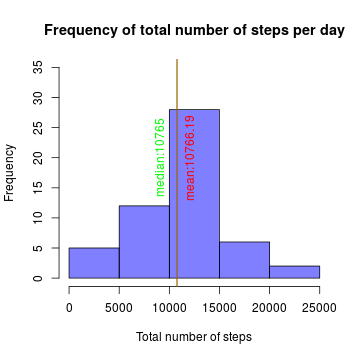

```r
# Reports results on the histogram
hist(tot, col = rgb(0, 0, 1, 0.5), main = "Frequency of total number of steps per day",
    xlab = "Total number of steps", ylab = "Frequency", ylim = c(0, 35))
# add mean and median to the plot
abline(v = c(mediantot, meantot), col = c("green", "red"))
text(9000, 20, paste("median", mediantot, sep = ":"), col = "green", srt = 90)
text(12000, 20, paste("mean", round(meantot, 2), sep = ":"), col = "red", srt = 90)
```

As it can be observed the median and the mean of the vector are very close (median=10765 and mean=1.0766 × 10<sup>4</sup>), so it's not possible to distinguish them from the plot

## What is the average daily activity pattern?

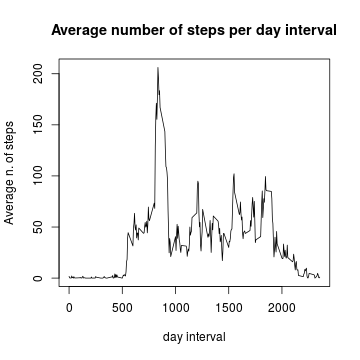

```r
# average number of steps per day interval
AvOnInt <- tapply(data$steps, data$interval, mean, na.rm = TRUE)
# AvOnInt
plot(x = names(AvOnInt), y = AvOnInt, type = "l", main = "Average number of steps per day interval",
    xlab = "day interval", ylab = "Average n. of steps")
```

```r
# Which 5-minute interval, on average across all the days in the dataset,
# contains the maximum number of steps?
maxAvInt <- AvOnInt[AvOnInt == max(AvOnInt)]
# Max number of steps
as.vector(maxAvInt)
```

```
## [1] 206.2
```

```r
# Time Interval
names(maxAvInt)
```

```
## [1] "835"
```

## Imputing missing values

```r
# calculates the total number of rows with NAs in the dataset
totNA <- nrow(data) - nrow(na.omit(data))
```

The dataset contains 2304 missing values over 17568 values

I decided to fill the NAs values with the average value for the corresponding five minute interval. I decided to use this strategy because in my opinion this value is closer to a possible “real” value that the daily average.

```r
# creates a new column (avonint) in the dataframe that contains the mean of
# the total number of steps in the time interval
data$avonint <- AvOnInt
# sets the steps value equals to the average value for the rows with NA
# steps
data["steps"][is.na(data["steps"])] <- data["avonint"][is.na(data["steps"])]
# creates a new dataset that is equal to the original one but with NAs
# filled in
newdata <- data[, 1:3]
# I need to convert 'steps' to an integer in order to have a new datafarame
# equal to the original one
newdata$steps <- as.integer(newdata$steps)

# make the new histogram with mean and median

# first we calculate the new total number of steps per day
newtot <- tapply(newdata$steps, newdata$date, sum)
# then we calculates the mean of the total number of steps per day: don't
# have NA's to ignore any more
newmeantot <- mean(newtot)
newmeantot
```

```
## [1] 10750
```

```r
# and the median
newmediantot <- median(newtot)
newmediantot
```

```
## [1] 10641
```

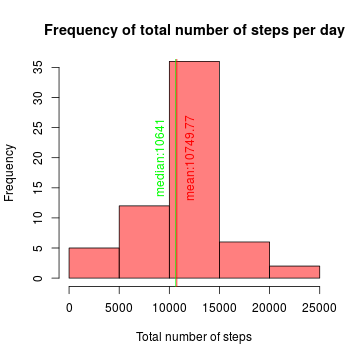

```r
# Reports results on the histogram
hist(newtot, col = rgb(1, 0, 0, 0.5), main = "Frequency of total number of steps per day",
    xlab = "Total number of steps", ylab = "Frequency", ylim = c(0, 35))
# add mean and median to the plot
abline(v = c(newmediantot, newmeantot), col = c("green", "red"))
text(9000, 20, paste("median", newmediantot, sep = ":"), col = "green", srt = 90)
text(12000, 20, paste("mean", round(newmeantot, 2), sep = ":"), col = "red",
    srt = 90)
```

If we compare the new histogram and the median and mean values to the previous ones, we see that the impact of setting the NAs to the interval average value did not have a significant impact on the values. In fact the mean and the median values didn't shift very much (just 0.1525% for the mean and 1.1519% for the median).

If we overlay the two histograms, although, we can easily evaluate the impact of imputing the NAs steps on the total daily number of steps:

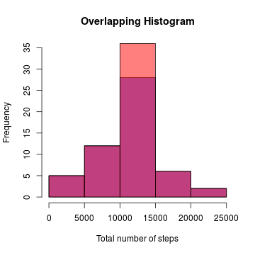

```r
hist(tot, col = rgb(0, 0, 1, 0.5), ylim = c(0, 35), main = "Overlapping Histogram",
    xlab = "Total number of steps", ylab = "Frequency")
hist(newtot, col = rgb(1, 0, 0, 0.5), add = T)
```

In process of substituting NAs with the average number of steps in the daily interval, we coerced the number to an integer and most of the values where rounded to 0's, especially the one relative to intervals in which the average number of steps was low. For this reason the impact is visible only in the central range (10000-15000 steps) where the total number of steps is now increased by the ex-NAs values that have been coerced to numbers greater than 0.

## Are there differences in activity patterns between weekdays and weekends?

Let's make a panel plot containing a time series plot of the 5-minute interval (x-axis) and the average number of steps taken, averaged across all weekday days or weekend days (y-axis). To this purpose I will first create two vectors with the average values, starting from the dataframe that has been cleaned from the NAs values and contains the weekday and weekend variable. I will then create a new dataframe that is suitable to build a plot using ggplot. I decided to work on the interval variable to express the time interval as a time (not as the interval number)

```r
# setting systime to have days in English
Sys.setlocale("LC_TIME", "C")
```

```
## [1] "C"
```

```r
# Adding a column to the dataframe that takes into account the day of the
# week
newdata$weekdays <- weekdays(as.Date(newdata$date), abbreviate = TRUE)
# adding a new column to store the weekend factor
newdata$isweekend <- "temp"
# setting the 'non weekend' values
newdata["isweekend"][newdata["weekdays"] != "Sun" | newdata["weekdays"] != "Sat"] <- "weekday"
# setting the weekend values
newdata["isweekend"][newdata["weekdays"] == "Sun" | newdata["weekdays"] == "Sat"] <- "weekend"
# cohercing the isweekend variable to factors
newdata$isweekend <- as.factor(newdata$isweekend)
# Now let's calculate the average number of steps per time interval in week
# days and in weekends
valswd <- tapply(newdata$steps[newdata$isweekend == "weekday"], newdata$interval[newdata$isweekend ==
    "weekday"], mean)
valswe <- tapply(newdata$steps[newdata$isweekend == "weekend"], newdata$interval[newdata$isweekend ==
    "weekend"], mean)
# let's store the data in a dataframe
dt <- cbind(data$interval[1:288], valswd, valswe)
dt <- as.data.frame(dt)
names(dt) <- c("interval", "weekday", "weekend")
# and reshape the dataframe to have a factor value that takes into account
# if the values are weekday's or weekend's vals
require(reshape2)
```

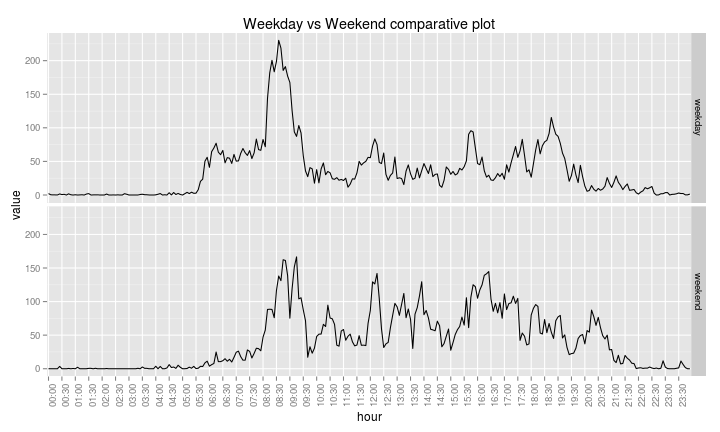

```r
ddt <- melt(dt, id.var = c("interval"), measure.var = c("weekday", "weekend"),
    variable.name = "day")
names(ddt) <- c("interval", "day", "value")
ddt <- melt(dt, id.var = c("interval"), measure.var = c("weekday", "weekend"),
    variable.name = "day")
names(ddt) <- c("interval", "day", "value")
ddt$hour <- sprintf("%02d:%02d", ddt$interval%/%100, ddt$interval%%100)
# We can finally plot our patterns using ggplot2
require(ggplot2)
ddt_plot2 <- ggplot(ddt, aes(x = hour, y = value, group = 1)) + geom_line()
ddt_plot2 + facet_grid(day ~ .) + scale_x_discrete(breaks = ddt$hour[seq(1,
    288, by = 6)]) + theme(axis.text.x = element_text(angle = 90, hjust = 1)) +
    labs(title = "Weekday vs Weekend comparative plot")
```

From the comparaison it seems clear that the start-up of the working day is almost at the same time while during the week end the day starts more smoothley and the activity (ment as the average number of steps) is more spread during the whole day.